# Probability of causation in individual workers: Lung cancer due to occupational exposure to asbestos

Authors

Javier Mancilla-Galindo¹, Susan Peters¹, Huifang Deng¹, Henk van der Molen², Hans Kromhout¹, Lützen Portengen¹, Roel Vermeulen¹, Dick Heederik¹˒³

1. Institute for Risk Assessment Sciences, Utrecht University, Utrecht, the Netherlands

2. Department of Public and Occupational Health, Amsterdam UMC, Amsterdam, the Netherlands

3. National Expertise Centre for Substance-related Occupational Diseases (Lexces), Utrecht, the Netherlands

**Abstract**

**Background:** Lung cancer compensation systems for occupational exposure to asbestos commonly apply Helsinki criteria, which assume 4% excess lung cancer risk per fibre-year of asbestos exposure. This results in a ‘Probability of Causation (PoC)’ ≥50% at 25 fibre-years (risk doubling threshold). Large recent case-control studies have suggested steeper exposure-response relations at lower exposures. We aimed to estimate PoC of asbestos-related lung cancer to evaluate exposure thresholds for compensation of lung cancer cases occupationally exposed to asbestos.

**Methods:** Relative risk of asbestos-related lung cancer was estimated using two approaches:

- A meta-regression of 22 occupational studies forming the core evidence on cumulative asbestos exposure and lung cancer since the 1980s (130,341 participants).
- A meta-analysis of the recently conducted SYNERGY pooled case-control study (14 studies, 37,866 participants), adjusted for age, sex, smoking, and study.

The likelihood that lung cancer was caused by asbestos was estimated as the PoC with 95% prediction intervals (95%PI).

**Results:** Occupational cohort studies produced a shallow exposure-response relation with substantial heterogeneity (I² = 92.7%). SYNERGY showed a steeper relation with 6.8% (95%PI: 0%–17.7%) lung cancer risk increase per fibre-year and lower heterogeneity (I² = 63.4%). PoC ≥50% occurred at 62.93 (point estimate) and 18.2 fibre-years (upper 95%PI) for occupational asbestos studies, compared to 10.5 and 4.3, respectively, in SYNERGY.

**Conclusions:** The SYNERGY pooled case-control study provided exposure-response estimates that are more representative of current exposure to lower mixed asbestos fibres in the Netherlands, supporting lower exposure thresholds than the existing Helsinki criteria when estimating PoC in compensation contexts.

**Keywords:** [*Asbestos*](https://www.ncbi.nlm.nih.gov/mesh/68001194)*, [Lung cancer](https://www.ncbi.nlm.nih.gov/mesh/68008175), Probability of Causation, [Causality](https://www.ncbi.nlm.nih.gov/mesh/68015984), [Workers’ Compensation](https://www.ncbi.nlm.nih.gov/mesh/68014942)*

# Key Messages

**What is already known on this topic**

- Probability of causation (PoC) is applied in workers’ compensation with a PoC ≥0.5 as criterion, typically corresponding to a doubling in baseline disease risk;
- An exposure threshold of 25 fibre-years is used as the doubling in risk criterion for lung cancer attribution (2014 Helsinki criteria) in compensation systems worldwide;
- Upper confidence intervals (statistical uncertainty) of the PoC have been suggested as eligibility thresholds for compensation to weigh uncertainties in favour of workers.

**What this study adds**

- This study uses recent and transparent quantitative meta-analyses for the relation between lung cancer and asbestos exposure instead of the Helsinki criterion of 25 fibre-years (4% extra risk per fibre year);
- This study applies upper 95% prediction intervals of PoC that reflect uncertainty because of between study differences in risk and is a more appropriate measure than statistical uncertainty of the meta-risk-estimate alone;
- Together with the use of recent general population studies a lower exposure thresholds (4.3 fibre-years) was obtained than when the Helsinki criterion was applied (25 fibre-years);
- In contrast, historical occupational cohort studies resulted in a threshold of 18.2 fibre-years.

**How this study might affect research, practice or policy**

- Prediction intervals are a useful tool to account for uncertainty arising from meta-analyses in compensation processes;
- Use of the prediction interval should be considered when the aim is to weigh uncertainties in favour of workers;
- Based on the results, 4.3 fibre-years are used as the threshold for compensation in The Netherlands.

# Introduction

Assessing whether diseases are caused by occupational exposures often occurs within national workers’ compensation systems. Determining causality between occupational exposure and disease requires integrating epidemiological, experimental animal, and mechanistic evidence, including toxicological findings.<sup><sup>1</sup></sup> Population-based epidemiological studies are particularly important as human evidence is critical for classifying agents as proven human carcinogens. Lung cancer, a high impact disease with individual and societal burden, has multiple causes, with cigarette smoking being the leading risk factor.<sup><sup>2</sup></sup> However, various occupational exposures also substantially increase lung cancer risk, including asbestos, respirable crystalline silica, diesel engine exhaust, arsenic, nickel, and chromium, which are classified as respiratory carcinogens.<sup><sup>2</sup>,<sup>3</sup></sup> Individual causality assessment is complicated for multi-causal diseases like lung cancer because different causal factors produce indistinguishable lung cancer clinical presentations, making it impossible to determine causation determine individual causation based on tumour histology. Despite this limitation, proof of causality at the individual level is often required for workers’ compensation.

One common approach is estimating the likelihood that a certain determinant (occupational exposure) caused lung cancer in a case, often applied as the probability of causation (PoC).<sup><sup>4</sup>,<sup>5</sup></sup> When PoC ≥0.5 (or 50%), the disease is “more likely than not” caused by the exposure, as excess risk equals or exceeds baseline risk (i.e., unexposed). This approach has been applied in various societal contexts including tort law and cancer compensation due to radiation,<sup><sup>6</sup>,<sup>7</sup></sup> coal tar pitch volatiles,<sup><sup>8</sup></sup> smoking,<sup><sup>9</sup></sup> among others. While early critiques focused on its omission of accelerated outcome occurrence and non-identifiability from observational data,<sup><sup>10</sup></sup> later work showed that PoC is identifiable under certain causal assumptions, mainly no outcome prevention and no confounding.<sup><sup>5</sup>,<sup>11</sup></sup>

PoC can be estimated from exposure-response relations observed in epidemiological studies or from meta-analyses.<sup><sup>9</sup></sup> However, it is sensitive to estimation errors arising from limitations in study design, conduct and analysis, such as exposure or disease measurement error and misclassification, confounding, causal model misspecification, and estimation imprecision. Therefore, it has been argued that uncertainties should benefit the claimant when applying the PoC.<sup><sup>7</sup>,<sup>8</sup>,<sup>12</sup></sup> Sources of error in asbestos exposure assessment include limited detection capability when sampling and analysis of fibres was not yet fully developed, difficulty applying consistent fibre-to-mass or fibre-type conversion factors in case of exposure studies conducted using different measurement techniques,<sup><sup>13</sup></sup> and incomplete or imprecise job histories, together generally resulting in underestimated or attenuated exposure-response, which has been estimated to be as large as a factor of 1.5 to 2.<sup><sup>14</sup>,<sup>15</sup></sup>

In the Netherlands, a compensation scheme for occupational diseases is in place since 2022, adopting the *presumably plausible principle (‘voorshands aannemelijk principe’)*, operationalised by considering uncertainties in favour of workers,<sup><sup>16</sup></sup> for a one-time (all or none) compensation.<sup><sup>17</sup></sup> Two main sources of uncertainty are considered: (1) uncertainties in reconstructing individual cumulative exposure when applying job-exposure matrices,<sup><sup>18</sup></sup> and (2) uncertainties in exposure-response.<sup><sup>17</sup></sup> Asbestos-related lung cancer was among the first occupational diseases included in January 2022.

Asbestos was completely banned in the Netherlands in 1993 following earlier bans on crocidolite in 1977 and asbestos spraying in 1978. Between 6,800 and 17,500 cases of asbestos-related lung cancer from pre-1993 exposures were projected for 2011 to 2030,<sup><sup>19</sup></sup> with ~600 new cases occurring in 2023.<sup><sup>20</sup></sup> In many countries, lifetime cumulative asbestos exposure of 25 fibre-years is considered the threshold for a doubling in lung cancer risk and compensation eligibility, resulting from the 4% excess risk per fibre-year as proposed in the 2014 Helsinki report.<sup><sup>21</sup></sup> However, this estimate has been criticized for lacking methodological transparency.<sup><sup>22</sup></sup> Specifically, the 4% value was not based on formal meta-analysis of all available evidence and assumes a linear exposure-response relation, inconsistent with recent studies indicating that exposure-response may be steeper at lower exposure and levels off at higher exposure.<sup><sup>23</sup></sup> Moreover, the exposure-response slope is significantly affected by study exposure assessment quality.<sup><sup>14</sup>,<sup>15</sup>,<sup>23</sup></sup>

In this study, we aimed to estimate the PoC of asbestos-related lung cancer, to evaluate exposure thresholds for financial compensation of lung cancer cases occupationally exposed to asbestos. We estimated exposure levels associated with a doubling in lung cancer risk (PoC ≥ 0.5) based on two series of studies:

- A meta-regression of studies with quantitative exposure-response relations, recently conducted as part of a systematic review for occupational standard setting in Europe by the European Chemicals Agency (ECHA). The study base consisted of 20 occupational cohorts and two case-control studies providing excess risk estimates for asbestos cumulative exposure categories to different types of asbestos in mining and production industries, including cohorts with mixed exposure. In most studies, information on cigarette smoking was not available.
- The study base created by ECHA contained a meta-analysis of a multi-country general population pooled case-control study, the SYNERGY study, which was also analysed separately as the only study with homogeneous exposure assessment across individual studies, covering populations exposed more recently, from a wide range of different occupational settings, to lower levels of mixed asbestos fibres, and data on important confounders (e.g., smoking).

# Methods

## Study design and setting

### Occupational asbestos studies

Occupational asbestos studies were most recently evaluated by the European Chemicals Agency (ECHA) using the systematic review by van der Bij, et al.,<sup><sup>23</sup></sup> an update of the initial review by Lenters, et al.,<sup><sup>14</sup></sup> which considered 19 epidemiological studies. ECHA updated risk assessment to derive an occupational exposure standard in 2021 by updating<sup><sup>24</sup>–<sup>26</sup></sup> or adding studies,<sup><sup>27</sup>–<sup>29</sup></sup> including SYNERGY,<sup><sup>26</sup></sup> a pooled case-control study described below. Characteristics of the occupational studies are presented in **Table 1**. The occupational cohort studies were conducted in different countries, in earlier periods than SYNERGY, and mainly involve mining and specific asbestos production industries, using different asbestos types depending on product requirements. Each study had its exposure assessment component (**Supplementary Table 1**), with most estimating workers’ lifetime cumulative asbestos exposure using job exposure matrixes (JEM), and further categorizing by cumulative exposure to estimate excess lung cancer risk. Because these studies started in different periods and exposed populations were followed over several decades, different techniques were used between and within studies to measure asbestos: counting dust particles (e.g., impinger) in earlier periods and, more recently, quantifying fibres (e.g., phase contrast microscopy). This often required applying particle-to-fibre conversion factors between and within studies. Accordingly, studies were rated by Lenters, et al.<sup><sup>14</sup></sup> and ECHA<sup><sup>15</sup></sup> for exposure assessment quality (low/high) based on documentation, exposure contrast, conversion factors (internal/external), measurement period coverage relative to population exposure, and job history sufficiency.

### SYNERGY study

The SYNERGY study was also analysed separately as the only study with homogeneous exposure assessment and data on important confounders (e.g., smoking habits). SYNERGY is a pooled case-control study on occupational carcinogen risk for lung cancer development, collecting data from 14 case-control studies conducted across Europe and Canada (1985–2010), comprising 17,705 lung cancer cases and 21,813 controls (**Table 2**). Lung cancer cases with histological or cytological confirmation were included with overall response rate of 83% (range: 62–98%). Controls were mostly recruited from general population (79% vs 21% hospitals), with response rate of 70% (range: 41–100%), and were frequency-matched on age and sex. A nested case-control study within MORGEN, and studies LUCA and ICARE used density sampling, while the remaining employed cumulative incidence sampling. Odds ratios can thus be interpreted as rate and risk ratios, respectively, which converge<sup><sup>30</sup></sup> because lung cancer is relatively rare and asbestos exposure prevalence remains stable over short recruitment windows relative to the long latency of asbestos.

Cumulative occupational asbestos exposure was estimated using the quantitative *SYN-JEM*,<sup><sup>31</sup></sup> developed using 27,958 asbestos exposure measurements. SYN-JEM estimates annual average job (ISCO-68), year and region-specific asbestos exposure in fibre-year (ff/ml-year) which were consequently summed to yield cumulative exposure in fibre-years. The SYN-JEM model incorporated effects of country-specific asbestos bans and has been applied in studies on occupational asbestos exposure and asbestos-related diseases: peritoneal mesothelioma,<sup><sup>32</sup></sup> asbestosis,<sup><sup>33</sup></sup> and lung cancer.<sup><sup>26</sup></sup>

**Table 1**. Studies included in the study base for occupational standard setting in Europe by the European Chemicals Agency (ECHA) on quantitative asbestos exposure and lung cancer.

| Study | Asbestos Exposure Period | Study design | N | Type of risk estimate | Fibre type | Lowest–highest exposure category (f–y/cm³) | Exposure quality <sup>d</sup> | Lagged CE |
| --- | --- | --- | --- | --- | --- | --- | --- | --- |
| Quebec, Canada, mines and mills | ~ 1904–1976 | Cohort | ∼11,000 | SMR | Chrysotile | 4.7–4,710 | Low | CE to age 55 |
| Italy, Balangero, mine and mill | 1916–1990 | Cohort | 1,056 | SMR | Chrysotile | 50–667 | Low | CE |
| Connecticut, friction product plant | 1913–1977 | Cohort | 3,513 | SMR | Chrysotile | 15–400 | Low | CE |
| South Carolina, textile plant | 1896–1977 | Cohort | 3,072 | SMR | Chrysotile | 0.75–200 | High | CE10 |
| North Carolina, textile plant | 1925–1994 | Cohort | 5,770 | RR adj <sup>a</sup> | Chrysotile | 5.7–408 <sup>c</sup> | Low | CE10 |
| Wittenoom, Australia, mine | 1937–1966 | Cohort | 6,358 | SMR | Amphibole, crocidolite | 0.11–220 | Low | CE |
| Patterson, NJ, insulation manufacture | 1941–1954 | Cohort | 820 | SMR | Amphibole, amosite | 3–417 | Low | CE |
| Tyler, TX, insulation manufacture | 1954–1972 | Cohort | 1,121 | SMR | Amphibole, amosite | 11–375 | High | CE |
| Libby, MT, mines and mills | 1935–1990 | Cohort | 1,862 | RR | Amphibole, tremolite <sup>b</sup> | 0.7–73 | High | CE20 |
| UK, friction products factory | 1910–1979 | Nested case-control | 13,460 | OR | Mixed | 29.5–228 <sup>c</sup> | Low | CE |
| Ontario, asbestos cement plant | 1948–1977 | Cohort | 740 | SMR | Mixed | 15–250 | Low | CE |
| New Orleans, LA, asbestos cement plants | 1937–1972 | Cohort | 6,931 | SMR | Mixed | 4.2–256 | Low | CE10 |
| Sweden, asbestos cement plant | 1907–1977 | Cohort (external reference) | 2,898 | RR adj <sup>a</sup> | Mixed | 3.1–88 | Low | CE |
| Belgium, asbestos cement plant | 1928–1977 | Cohort | 1,973 | SMR | Mixed | 25–2,000 | Low | CE |
| US factory retirees (Johns Manville) | 1890–1980 | Cohort | 1,074 | SMR | Mixed | 186–2,928 | High | CE |
| US and Canada, insulation workers | ~ 1920–1986 | Cohort | 17,800 | SMR | Mixed | 38–375 | Low | CE10 |
| Pennsylvania, textile plant | ~ 1900–1967 | Cohort | 4,024 | SMR | Mixed | 15–330 | High | CE10 |
| Rochdale, UK, textile plant | 1933–1978 | Cohort | 3,211 | SMR | Mixed | 5.9–257 | High | CE5 |
| Calvados, France, textile and friction product plant | 1978–2004 | Cohort | 2,024 | HR adj <sup>a</sup> | Mixed | 90–500 ᶜ | Low | CE10 |
| China, textile, rubber product and cement plant | 1972–2008 | Cohort | 577 | HR adj <sup>a</sup> | Chrysotile | 156–913 <sup>c</sup> | Low | CE10 |
| China, mine | 1981–2006 | Cohort | 1,539 | SMR | Chrysotile | 10–750 | Low | CE10 |
| Europe and Canada pooled case-control study | 1922–2009 | Case-control | 17,705 cases, 21,813 controls | OR adj <sup>a</sup> | Mixed | 0.25–4.7 | High | CE |

These studies are described in detail in the documentation connected to the Opinion of the Risk Assessment Committee of the European Chemicals Agency (in total 22 studies, N = 130341 participants).<sup><sup>15</sup></sup> References for the individual studies are provided in the supplementary materials.

Abbreviations: Adjusted (adj), cumulative exposure (CE), hazard ratio (HR), odds ratio (OR), risk ratio (RR), standardised mortality ratio (SMR).

<sup>a</sup> In the North Carolina textile plants study, results were adjusted for age, gender, race, calendar year, and birth cohort; In the Swedish cement plant study, results were adjusted for age and calendar year; In the Calvados plant study, results were adjusted for age and gender; In the Chinese textile, rubber product and cement plant study, results were adjusted for age and smoking (ever/never); In the Europe/Canada pooled case-control study, results were adjusted for study, age, smoking (pack-years, time-since-quitting smoking), and ever-employment in jobs with known increased lung cancer risk due to factors other than asbestos (Yes/No).

<sup>b</sup> Exposure in the Libby cohort is for the so-called Libby amphibole that includes tremolite and closely related fibrous amphiboles (winchite and richterite).

<sup>c</sup> The lowest exposure category (corresponding to 0.383 f–y/cm³ in the North Carolina textile plant and 4.5 f–y/cm³ in the British friction factory, 20 f–y/cm³ in the Calvados plant and 44.5 f–y/cm³ in the Chinese textile, rubber product and cement plant) was excluded as no risk estimate could be calculated because it was used as the reference category.

<sup>d</sup> Assitional details on the exposure assessment per study are provided in **supplementary table 1**.

**Table 2**. Description of studies included in the SYNERGY project.

| Study | Country | Period of recruitment | Sampling <sup>a</sup> | Source of Controls <sup>b</sup> | Interviewee <sup>c</sup> | Cases (N) | Response cases (%) | Controls (N) | Response controls (%) | Female (N) | Male (N) |
| --- | --- | --- | --- | --- | --- | --- | --- | --- | --- | --- | --- |
| AUT | Germany | 1990–1995 | C | P | S | 3180 | 77 | 3249 | 41 | 1068 | 5361 |
| HdA | Germany | 1988–1993 | C | P | S | 1004 | 69 | 1002 | 68 | 330 | 1676 |
| EAGLE | Italy | 2002–2005 | C | P | S | 1908 | 87 | 2065 | 72 | 875 | 3098 |
| TURIN | Italy | 1990–1994 | C | P | S | 1086 | 79 | 1489 | 80 | 404 | 2171 |
| ROME | Italy | 1993–1996 | C | H | S | 326 | 74 | 321 | 63 | 99 | 548 |
| LUCA | France | 1989–1992 | D | H | S | 280 | 98 | 282 | 98 | NA | 562 |
| PARIS | France | 1988–1992 | C | H | S | 169 | 95 | 227 | 95 | 19 | 377 |
| ICARE | France | 2001–2007 | D | P | S & NOK | 2739 | 87 | 3449 | 81 | 1331 | 4857 |
| CAPUA | Spain | 2000–2010 | C | H | S | 559 | 91 | 512 | 96 | 102 | 969 |
| MORGEN <sup>d</sup> | Netherlands | 1993–1997 | D (nested) | P | S | 43 | NA | 115 | NA | 78 | 80 |
| INCO Czech Republic | Czech Republic | 1999–2002 | C | H | S | 304 | 94 | 452 | 80 | 228 | 528 |
| INCO Hungary | Hungary | 1998–2001 | C | H | S | 391 | 90 | 305 | 100 | 139 | 557 |
| INCO Poland | Poland | 1998–2002 | C | P & H | S | 793 | 88 | 835 | 88 | 793 | 835 |
| INCO Slovakia | Slovakia | 1998–2002 | C | H | S | 345 | 90 | 285 | 84 | 107 | 523 |
| INCO Romania | Romania | 1998–2002 | C | H | S | 179 | 90 | 225 | 99 | 113 | 291 |
| INCO Russia | Russia | 1998–2001 | C | H | S | 599 | 96 | 580 | 90 | 156 | 1023 |
| INCO UK | United Kingdom | 1998–2005 | C | P | S | 441 | 78 | 916 | 84 | 504 | 853 |
| LUCAS | Sweden | 1985–1990 | C | P | S & NOK | 1014 | 87 | 2307 | 85 | NA | 3321 |
| MONTREAL | Canada | 1996–2002 | C | P | S & NOK | 1176 | 85 | 1505 | 69 | 1073 | 1608 |
| Toronto | Canada | 1997–2002 | C | P & H | S | 365 | 62 | 844 | 71 | 679 | 530 |

Frequencies of participants included for analysis are presented. References for the individual studies are provided in the supplementary materials.

<sup>a</sup> C = Cumulative, D = Density.

<sup>b</sup> P = Population, H = Hospital.

<sup>c</sup> S = Subject, NOK = Next-of-kin.

<sup>d</sup> Nested case-control study: 45% of invited participants to the original cohort completed the baseline questionnaire.

## Statistical Analysis

### Exposure-response estimation

Exposure-response relations in the 22 occupational asbestos studies were estimated with random-effects meta-regression of study-level logRR and average exposure level per category reported. A meta-RR was estimated from meta-regression of fixed-effects estimates (**Supplementary Methods**).<sup><sup>23</sup></sup>

A one-stage meta-analysis<sup><sup>34</sup></sup> of SYNERGY was used to estimate the relation between lung cancer RR and lifetime cumulative asbestos (**Supplementary Methods**). Meta-estimates were obtained with a generalized linear mixed model (logit link) with study-specific random intercepts and random slopes for cumulative asbestos exposure in fibre-years to account for between-study heterogeneity. The model was adjusted by including fixed effects for sex, study, age group (<45, 45–49, 50–54, 55–59, 60–64, 65–69, 70–74, and >74 years), smoking (cigarette pack-years [log (cigarette pack-years +1)] and time-since-quitting smoking cigarettes (current smokers; stopping smoking 2–7, 8–15, 16–25, ≥26 years before interview/diagnosis; and never-smokers).

### Heterogeneity and prediction intervals

Between-study heterogeneity was quantified using the I² statistic, representing the proportion of variation attributable to genuine differences between studies rather than sampling error.<sup><sup>35</sup></sup> In SYNERGY, exposure-response heterogeneity was obtained from two-stage univariate meta-analysis (**Supplementary Methods**). Higher I² values indicate greater inconsistency in estimated effects across studies beyond expected by chance.

For both meta-analyses, 95% prediction intervals (PI) were calculated using the approach described by Higgins, et al.<sup><sup>36</sup></sup> assuming normally distributed effects. This method combines squared standard error of the target effect with estimated between-study variance. For occupational studies, the target was the pooled logRR and in SYNERGY, the asbestos exposure-response slope coefficient. The prediction interval represents the range where the true effect estimate from a new study would be expected to fall, accounting for both sampling uncertainty and between-study heterogeneity as uncertainty measure.

### Probability of Causation

PoC for individual cases was estimated as the lower bound of the probability of necessity,<sup><sup>5</sup></sup> using the difference between risk under exposure ($\text{Risk}_{\text{exp}}$) and baseline risk ($\text{Risk}_{\text{unexp}}$), divided by $\text{Risk}_{\text{exp}}$. For quantitative exposures, PoC can be estimated using RR at exposure value ($x$) from the exposure-response relation:<sup><sup>8</sup>,<sup>9</sup></sup>

$${PoC}(x) \;≥\; \frac{RR(x)\;-\;1}{RR(x)}$$

This equation was solved for $PoC(x) ≥ 0.5$ for both exposure-response relations to obtain exposure compensation thresholds. Lung cancer cases with PoC ≥ 0.5 are reported as total count of compensated cases and rate per 10,000 cases using the SYNERGY population as reference. Besides PoC point estimates, upper limits of 95% PI were estimated to account for uncertainties in exposure-response relations (*presumably plausible* threshold).

### Sensitivity Analysis

The exposure-response in occupational asbestos studies was re-estimated by excluding SYNERGY. SYNERGY exposure-response relations were re-estimated stratifying by control source (hospital-based and population-based), since hospital-based controls have greater baseline disease risk than population-based controls, resulting in potential effect underestimation. Additional sensitivity analyses considered alternative meta-analysis configurations (**Supplementary Methods**).

Analyses and visualizations were performed in R v.4.5.1 through RStudio v.2025.05.1. Code and documentation are available at https://github.com/UtrechtUniversity/PoC-Asbestos.

# Results

Most occupational studies (in total 22 studies, N = 130341 participants) are cohorts estimating standardised mortality ratios for a range of exposure categories (**Table 1**). Only two studies<sup><sup>26</sup>,<sup>28</sup></sup> estimated smoking-adjusted relative risks. Asbestos exposure periods range from 1890 to 2009 (16 studies with exposure starting before World War II). Risk estimates correspond to cumulative asbestos exposures up to 4710 fibre-years (median 79.9, IQR 17.5 – 250.3; excluding SYNERGY: median 90, IQR 25.5 – 256.3). Exposure assessment quality was rated high in 7 studies and low in 15 due to poor documentation, low exposure contrast, use of external instead of study-specific fibre conversion factors, incomplete job histories, or incomplete exposure coverage during follow-up.<sup><sup>14</sup></sup>

A summary of the fourteen studies included in SYNERGY is shown in **Table 2**, and characteristics of the study population (N = 37866) in **Table 3**. Exposure to asbestos for the SYNERGY participants had to be estimated from 1922 to 2009. Ever exposure to asbestos was reported in 39% (n = 14752) participants. Cumulative asbestos exposure in SYNERGY ranged from 0.002 to 64.6 fibre-years (median 1.33, IQR: 0.55 – 3.22). The percentage of asbestos exposure in lung cancer cases and controls was 44% (n = 7440/16901) and 34.9% (n = 7312/20965), respectively. Median lifetime cumulative exposure to asbestos in ever-exposed was 1.54 (IQR: 0.62 – 3.53, range: 0.002 – 35.43) fibre-years in cases and 1.17 (IQR: 0.48 – 2.86, range: 0.002 – 64.6) fibre-years in controls. Total exposure duration in the cases and controls was 15.5 (IQR: 6 – 31, range: 1 – 62) years and 14 (IQR: 5 – 30, range: 1 – 63) years, respectively.

**Table 3**. Descriptive characteristics of SYNERGY study participants.

|  | Total (N=37866) | Controls (N=20965) | Lung cancer cases (N=16901) |
| --- | --- | --- | --- |
| sex |  |  |  |
| Female | 7810 (20.6%) | 4514 (21.5%) | 3296 (19.5%) |
| Male | 30056 (79.4%) | 16451 (78.5%) | 13605 (80.5%) |
| Age |  |  |  |
| Mean (SD) | 61.7 (9.63) | 61.5 (9.92) | 62.0 (9.23) |
| Asbestos (ff/ml-years) |  |  |  |
| Mean (SD) | 2.42 (3.01) | 2.22 (3.01) | 2.60 (3.00) |
| Median (Q1, Q3) | 1.33 (0.550, 3.22) | 1.17 (0.476, 2.86) | 1.54 (0.622, 3.53) |
| Min, Max | 0.00214, 64.6 | 0.00229, 64.6 | 0.00214, 35.4 |
| Never exposed | 23114 (61.0%) | 13653 (65.1%) | 9461 (56.0%) |
| Exposure duration (years) |  |  |  |
| Mean (SD) | 18.4 (13.9) | 17.9 (13.8) | 18.9 (14.0) |
| Median (Q1, Q3) | 15.0 (6.00, 30.0) | 14.0 (5.00, 30.0) | 15.5 (6.00, 31.0) |
| Min, Max | 1.00, 63.0 | 1.00, 63.0 | 1.00, 62.0 |
| Never exposed | 23114 (61.0%) | 13653 (65.1%) | 9461 (56.0%) |
| Smoking |  |  |  |
| Never smoker | 8522 (22.5%) | 7153 (34.1%) | 1369 (8.1%) |
| Former smoker | 13652 (36.1%) | 8220 (39.2%) | 5432 (32.1%) |
| Current smoker | 15692 (41.4%) | 5592 (26.7%) | 10100 (59.8%) |
| Pack-years |  |  |  |
| Median (Q1, Q3) | 23.3 (1.60, 41.5) | 9.75 (0, 29.1) | 35.8 (21.0, 51.0) |
| Time since quitting smoking |  |  |  |
| 0-7 years | 3448 (9.1%) | 1422 (6.8%) | 2026 (12.0%) |
| 8-15 years | 3429 (9.1%) | 1898 (9.1%) | 1531 (9.1%) |
| 16-25 years | 3517 (9.3%) | 2346 (11.2%) | 1171 (6.9%) |
| >25 years | 3258 (8.6%) | 2554 (12.2%) | 704 (4.2%) |

> Abbreviations: fibre-years (ff/ml-years), maximum (Max), minimum (Min), 25th percentile (Q1), 75th percentile (Q3), standard deviation (SD).

### Exposure-response and PoC

In the meta-analysis of the 22 occupational studies (I² = 92.7%), lung cancer RR doubled at 62.9 fibre-years, and 18.2 fibre-years when using the upper limit of the 95% PI (**Figure 1A**). If these thresholds were to be applied to the lung cancer cases and their cumulative asbestos exposure estimate from the SYNERGY population, 0 and 17 lung cancer cases per 10,000 would be entitled to compensation under the point estimate and presumably plausible threshold, respectively (**Table 4**). Exclusion of SYNERGY from the database yielded an exposure-response relation with similar heterogeneity (I² = 92.9%) and lung cancer risk doubling threshold of 84.1 fibre-years and 26.6 with the upper 95% PI (**Supplementary Table 4**).

The exposure-response relation in SYNERGY (I² = 63.4%) modelled as a linear function of cumulative asbestos exposure (fibre-years) yielded a 6.8% lung cancer risk increase per fibre-year, with upper PI of 17.7% (**Figure 1A**). Study-specific estimates and results of the two-stage meta-analysis are presented in **Supplementary Figure 2** and **Supplementary Table 5**. In the one-stage meta-analysis, lung cancer risk is doubled at 10.5 fibre-years for the point estimate and 4.3 fibre-years under the presumably plausible threshold (**Figure 1B**), resulting in 117 and 857 compensated cases per 10,000, respectively (**Table 4**).

In the sensitivity analysis, a steeper exposure-response (**Supplementary Figure 3**) was observed for studies with population-based controls (10.2% risk increase per fibre-year) compared to studies with hospital controls (2.3% risk increase per fibre-year), with large shifts in PoC ≥ 0.5 thresholds (**Supplementary Figure 4**) for the point estimates, but limited impact in the presumably plausible threshold for population controls compared to the average SYNERGY effect (**Table 4**).

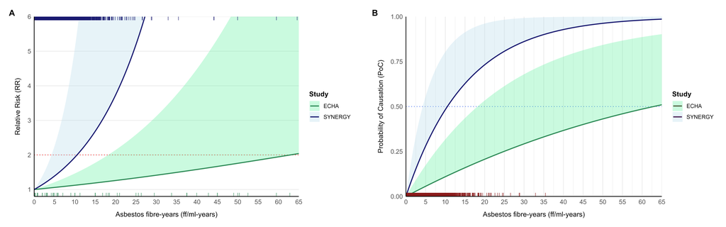

**Figure 1**. Exposure response relations of lung cancer risk increase (**A**), and Probability of Causation of lung cancer (**B**) across the range of lifetime cumulative exposure to asbestos (fibre-years) values in SYNERGY. Solid lines represent the average meta-estimates; shaded areas, the upper 95% prediction intervals, and the dotted lines, the doubling in increase of risk threshold (red) and PoC 0.5 threshold (blue). Vertical tick marks represent average exposure values for the reported pooled estimates per exposure category in the study base by ECHA (green, bottom), individual participant exposure values in the total SYNERGY population (blue, top), and lung cancer cases in SYNERGY (red, bottom).

**Table 4**. Number of compensated cases per 10,000 lung cancer cases according to various scenarios applied to the lung cancer cases (n = 16901) within the SYNERGY population. It was estimated at what cumulative asbestos exposure (fibre-years) the probability of causation (PoC) is equal or larger than 50%.

| Model | Risk Increase per Fibre-year<sup>a</sup> Estimate | Risk Increase per Fibre-year<sup>a</sup> 95% Prediction Interval | Min Exposure for 50% PoC (fibre-years)<sup>b</sup> Point Estimate | Min Exposure for 50% PoC (fibre-years)<sup>b</sup> Presumably Plausible | Cases per 10,000 above 50% PoC in SYNERGY Point Estimate | Cases per 10,000 above 50% PoC in SYNERGY Presumably Plausible |
| --- | --- | --- | --- | --- | --- | --- |
| Meta-regression of published occupational studies including SYNERGY |  |  |  |  |  |  |
| Spline | 1.1% | [0%, 3.6%] | 62.93 | 18.19 | 0 | 17 |
| Meta-analysis of SYNERGY studies only |  |  |  |  |  |  |
| Main | 6.8% | [0%, 17.7%] | 10.52 | 4.26 | 117 | 857 |
| Sensitivity analysis of SYNERGY studies, stratified by source of controls |  |  |  |  |  |  |
| Population controls | 10.2% | [3%, 17.8%] | 7.16 | 4.23 | 344 | 866 |
| Hospital controls | 2.3% | [0%, 8.7%] | 29.90 | 8.32 | 1 | 231 |

<sup>a</sup> Negative values truncated to 0 due to monotonicity assumption. For spline model: instantaneous slope at 1.5 fibre-years (median exposure in cases).  
<sup>b</sup> Probability of Causation (PoC) of 50% corresponds to a doubling in lung cancer risk (i.e., RR = 2) for the point estimate and the upper 95% prediction interval for the presumably plausible threshold.

# Discussion

- **Study quality, including the exposure assessment component**. An important limitation of the occupational cohort studies meta-regression is the clear indication of exposure-response underestimation due to individual study limitations, particularly varying exposure assessment quality. This issue is widely recognised in occupational epidemiology due to exposure misclassification and measurement error, discussed in the context of asbestos.<sup><sup>14</sup>,<sup>37</sup></sup> Other potential biases include confounding from unmeasured confounders, particularly cigarette smoking, and possibly selection bias due to the healthy worker effect in the occupational cohort studies, the latter often resulting in effect underestimation.<sup><sup>38</sup></sup> Differences in study quality among the occupational cohort studies likely explain much of the between-study heterogeneity (I² = 92.7%).<sup><sup>14</sup></sup>
- Cumulative asbestos exposure in SYNERGY is based on SYN-JEM,<sup><sup>31</sup></sup> which has the advantage of assigning values with one method based on modelled personal measurements of asbestos exposure across the pooled case-control studies. However, it potentially introduces Berkson-type error by using average exposure values,<sup><sup>39</sup></sup> resulting in imprecise (wider confidence intervals) exposure-response estimation.<sup><sup>40</sup></sup> Berkson-type error is also present in industrial cohort studies since exposures are also assigned at job level. but often at a more refined level than in general population studies (company-specific job codes versus ISCO-68). Unlike industrial cohort studies, SYNERGY shows less effect heterogeneity (I² = 63.4%). While most measurements used to develop SYN-JEM used phase contrast microscopy (PCM) with a lower limit of detection (LOD) of ~2,000 fibres/m³, 5% used electron microscopy (EM) with LOD 100 to 200 fibres/m³.<sup><sup>13</sup></sup> In contrast, only one<sup><sup>28</sup></sup> of the industrial cohort studies used EM besides PCM and particle counting, whereas many applied conversion factors due to changes in analytic techniques over time, some study specific, some assessed in other studies.<sup><sup>14</sup></sup>
- **Other reasons for study heterogeneity**. Exposure to different asbestos types may have contributed to between-study differences. However, potency difference between fibre types are considerably smaller for lung cancer than for mesothelioma.<sup><sup>41</sup></sup> Moreover, the analysis by van der Bij et al.<sup><sup>23</sup></sup> using a spline model instead of assuming linearity of the exposure response relation, as well as the analysis by ECHA,<sup><sup>15</sup></sup> suggest that the potency differences for lung cancer are even smaller than previously indicated by simple linear models rather than more advanced spline models, which more adequately describe the exposure-response relation.
- **Relevance for asbestos risk assessment**. The industrial cohorts describe lung cancer risk at the high end of the exposure distribution, whereas case-control studies describe risk at considerably lower exposure levels. Most industrial cohorts included workers who started working before World War II and have been updated with additional follow-up, resulting in higher numbers of deceased workers and increased power to detect associations. However, exposure assessment for these early periods is inherently uncertain, as systematic personal air sampling was not routinely conducted before the 1970s. This allowed more detailed exploration of the shape of the association between exposure and disease. Nonetheless, industrial cohort studies often excluded workers with short employment duration (i.e., <1 year employed). The number of observations at the low end of the exposure distribution (e.g., below 25-50 fibre-years) is limited for the occupational cohorts and knowledge about the risk at this level is strongly dependent on extrapolation to lower exposure levels and models used for extrapolations, which mostly assumed linearity.
- Initial observations of increased asbestos health risk emerged in mining and industries processing asbestos in products like textile, asbestos cement, brake lining, and shipyards (asbestos insulation). Currently, elevated risk occurs in workers from industries not involved in primary asbestos production. A recent UK mesothelioma case-control study shows a clear shift in risk for the working population from primary production, where the first excess risks were observed, due to occupational asbestos exposure, to downstream industries, such as construction, since World War II.<sup><sup>42</sup></sup>

On the basis of these analyses, the Advisory Committee for the List of Occupational Diseases in the Netherlands advised the Minister of Social Affairs and Employment that the lifetime cumulative exposure threshold of 4.3 fibre-years based on SYNERGY meta-estimates to compensate workers occupationally exposed to asbestos is defensible. This threshold aligns better with the expected burden of asbestos-related lung cancer in the Netherlands, estimated at 426 per 10,000 cases, using the cumulative exposure information from SYNERGY lung cancer cases to obtain a population burden estimate. Most recent general population estimates of the lung cancer burden in the Netherlands projects 600 new asbestos-related lung cancer cases, based on registered mesothelioma cases and an assumed lung cancer/mesothelioma ratio,<sup><sup>20</sup></sup> out of 14,089 cases diagnosed nationally in 2023.<sup><sup>43</sup></sup> In contrast, estimates from cohort studies would result in few compensated workers, far below this expected burden. As a secondary consideration, Dutch workers currently applying for compensation were more recently exposed at lower mixed asbestos fibre levels.

The PoC is easily communicated to medical specialists, occupational health specialists, patients, and stakeholders as an eligibility criterion for financial compensation. Nonetheless, harm definition is linked to a doubling in lung cancer risk.<sup><sup>44</sup></sup> Asbestos is a no-threshold lung carcinogen, meaning any exposure level can increase lung cancer risk. Therefore, PoC ≥0.5 should not be interpreted as definitive evidence that lung cancer was caused by asbestos, but as a commonly used public health decision-making tool. While exposure-response-based PoC allows personalised decisions with individual cumulative exposure, it relies on population-average effects, not accounting for heterogeneity in occupational exposures nor timing of cancer occurrence. Applying uncertainties in the favour of claimants for workers’ compensation has been common practice to balance the limitations of the PoC.<sup><sup>7</sup>,<sup>8</sup>,<sup>12</sup></sup> Future directions for legal applications and workers’ compensation could involve decision-making using health outcomes accounting for accelerated occurrence<sup><sup>45</sup></sup> and different dimensions of affection, such as loss of life expectancy,<sup><sup>46</sup></sup> years of working life lost,<sup><sup>47</sup></sup> disability-adjusted life years,<sup><sup>48</sup></sup> or loss of income.<sup><sup>49</sup></sup>

# Conclusions

SYNERGY meta-analysis likely provided more reasonable estimates of asbestos-related lung cancer than traditional meta-regression of industrial cohort studies, given current occupational exposure to lower levels of generally mixed asbestos fibres in the Netherlands. Steeper exposure-response relations in SYNERGY with lower between-study heterogeneity translate into lower cut-off for compensation using the presumably plausible threshold. Therefore, an exposure threshold of 4.3 fibre-years was selected for the one-time compensation of workers occupationally exposed to asbestos in the Netherlands who develop lung cancer.

## Acknowledgements

We extend our sincere appreciation to the SYNERGY study group and the principal investigators of the original studies: https://synergy.iarc.fr/collaborators/.

## Funding

This work was supported by the Dutch Ministry of Social Affairs and Employment, grant number 25719.

## Ethics statement

The SYNERGY study was approved by the IARC Ethics Committee in addition to the individual study ethics approval.

## Competing interests

None reported.

## Data and code availability

Data are available upon reasonable request (inquiries can be directed to Dr. Susan Peters (s.peters@uu.nl). Alternatively, https://synergy.iarc.who.int/contact/.

The source code for this manuscript, statistical analyses, and project documentation is available through the online repository: https://github.com/UtrechtUniversity/PoC-Asbestos.

## AI-use statement

Claude (Anthropic) was used to assist with rephrasing text and improving English grammar and style throughout this manuscript. All AI-generated content was reviewed and edited by the authors, who take full responsibility for the final content

## References

1

Samet JM, Chiu WA, Cogliano V, *et al.* The IARC Monographs: Updated Procedures for Modern and Transparent Evidence Synthesis in Cancer Hazard Identification. *JNCI: Journal of the National Cancer Institute* 2020;**112**:30–7. doi:10.1093/jnci/djz169

2

Leiter A, Veluswamy RR, Wisnivesky JP. The global burden of lung cancer: Current status and future trends. *Nature Reviews Clinical Oncology* 2023;**20**:624–39. doi:10.1038/s41571-023-00798-3

3

IARC Working Group on the Evaluation of Carcinogenic Risks to Humans. Chemical agents and related occupations. *IARC monographs on the evaluation of carcinogenic risks to humans* 2012;**100**:9–562.

https://www.ncbi.nlm.nih.gov/books/nbk304416/

(accessed 7 Oct 2024).

4

Dawid AP, Musio M, Murtas R. The probability of causation. *Law, Probability and Risk* 2017;**16**:163–79. doi:10.1093/lpr/mgx012

5

Tian J, Pearl J. Probabilities of causation: Bounds and identification. *Annals of Mathematics and Artificial Intelligence* 2000;**28**:287–313. doi:10.1023/A:1018912507879

6

Ulanowski A, Shemiakina E, Güthlin D, *et al.* ProZES: The methodology and software tool for assessment of assigned share of radiation in probability of cancer occurrence. *Radiation and Environmental Biophysics* 2020;**59**:601–29. doi:10.1007/s00411-020-00866-7

7

Wakeford R. Occupational exposure, epidemiology and compensation. *Occupational Medicine* 2006;**56**:173–9. doi:10.1093/occmed/kql012

8

Armstrong B, Thériault G. Compensating lung cancer patients occupationally exposed to coal tar pitch volatiles. *Occupational and Environmental Medicine* 1996;**53**:160–7. doi:10.1136/oem.53.3.160

9

Siemiatycki J, Karp I, Sylvestre M-P, *et al.* Estimating the Proportion of Cases of Lung Cancer Legally Attributable to Smoking: A Novel Approach for Class Actions Against the Tobacco Industry. *American Journal of Public Health* 2014;**104**:e60–6. doi:10.2105/AJPH.2014.302040

10

Greenland S. Relation of probability of causation to relative risk and doubling dose: A methodologic error that has become a social problem. *American Journal of Public Health* 1999;**89**:1166–9. doi:10.2105/AJPH.89.8.1166

11

Kawakami Y, Kuroki M, Tian J. Probabilities of causation for continuous and vector variables. In: Kiyavash N, Mooij JM, eds. *Proceedings of the fortieth conference on uncertainty in artificial intelligence*. PMLR 2024. 1901–21.

https://proceedings.mlr.press/v244/kawakami24a.html

12

Merwin SE, Stewart DN, Smith MH, *et al.* Implications of claimant-favorable approaches used in dose and probability of causation calculations under EEOICPA. *Health Physics* 2008;**95**:148–59. doi:10.1097/01.HP.0000305824.21020.10

13

Franken R, Tromp P, Ervik TK, *et al.* European harmonization of asbestos exposure assessment: Comparing PCM, SEM, and TEM to derive conversion factors. *Annals of Work Exposures and Health* 2025;**69**:575–91. doi:10.1093/annweh/wxaf023

14

Lenters V, Vermeulen R, Dogger S, *et al.* A Meta-analysis of Asbestos and Lung Cancer: Is Better Quality Exposure Assessment Associated with Steeper Slopes of the Exposure–Response Relationships? *Environmental Health Perspectives* 2011;**119**:1547–55. doi:10.1289/ehp.1002879

15

Heederik D, Santonen T. Opinion on scientific evaluation of occupational exposure limits for Asbestos. European Chemicals Agency 2021.

https://echa.europa.eu/documents/10162/7937606/oel_asbestos_final_opinion_en.pdf/

(accessed 11 Nov 2024).

16

Zandwijk N van, Akkermans AJ, Coebergh JWW, *et al.* [Asbestos diseases protocols: Lung cancer] (in dutch). The Hague, Netherlands: : Health Council of the Netherlands 2005.

https://www.gezondheidsraad.nl/documenten/2023/09/04/advies-longkankersterfte-door-inhalatoire-blootstelling-aan-asbest

17

Coenen P, Kezic S, Heederik DJJ, *et al.* Applying a “presumably plausible” principle in a new one-time financial compensation system for occupational diseases in the Netherlands. *Occupational and Environmental Medicine* 2024;**81**:529–31. doi:10.1136/oemed-2024-109533

18

Kromhout H, Heederik DJJ. Using job exposure matrices to estimate an individual’s exposure for compensation? *Occupational and Environmental Medicine* Published Online First: 2026. doi:10.1136/oemed-2025-110290

19

Van Der Bij S, Vermeulen RCH, Portengen L, *et al.* Expected number of asbestos-related lung cancers in the Netherlands in the next two decades: A comparison of methods. *Occupational and Environmental Medicine* 2016;**73**:342–9. doi:10.1136/oemed-2014-102614

20

Heederik DJJ, Burdorf A, Burgers JA, *et al.* [Advice on lung cancer mortality due to inhalatory exposure to asbestos (in dutch)]. The Hague, Netherlands: : Health Council of the Netherlands 2023.

https://www.gezondheidsraad.nl/documenten/2023/09/04/advies-longkankersterfte-door-inhalatoire-blootstelling-aan-asbest

21

Wolff H, Vehmas T, Oksa P, *et al.* Asbestos, asbestosis, and cancer, the Helsinki criteria for diagnosis and attribution 2014: recommendations. *Scandinavian Journal of Work, Environment & Health* 2015;**41**:5–15. doi:10.5271/sjweh.3462

22

Baur X, Woitowitz H-J, Budnik LT, *et al.* Asbestos, asbestosis, and cancer: The Helsinki criteria for diagnosis and attribution. Critical need for revision of the 2014 update. *American Journal of Industrial Medicine* 2017;**60**:411–21. doi:10.1002/ajim.22709

23

Van Der Bij S, Koffijberg H, Lenters V, *et al.* Lung cancer risk at low cumulative asbestos exposure: Meta-regression of the exposure–response relationship. *Cancer Causes & Control* 2013;**24**:1–12. doi:10.1007/s10552-012-0107-7

24

Pira E, Romano C, Donato F, *et al.* Mortality from cancer and other causes among Italian chrysotile asbestos miners. *Occupational and Environmental Medicine* 2017;**74**:558–63. doi:10.1136/oemed-2016-103673

25

Larson TC, Antao VC, Bove FJ. Vermiculite Worker Mortality: Estimated Effects of Occupational Exposure to Libby Amphibole. *Journal of Occupational & Environmental Medicine* 2010;**52**:555–60. doi:10.1097/jom.0b013e3181dc6d45

26

Olsson AC, Vermeulen R, Schüz J, *et al.* Exposure–Response Analyses of Asbestos and Lung Cancer Subtypes in a Pooled Analysis of Case–Control Studies: *Epidemiology* 2017;**28**:288–99. doi:10.1097/EDE.0000000000000604

27

Clin B, Morlais F, Launoy G, *et al.* Cancer incidence within a cohort occupationally exposed to asbestos: a study of dose-response relationships. *Occupational and Environmental Medicine* 2011;**68**:832–6. doi:10.1136/oem.2010.059790

28

Courtice MN, Wang X, Lin S, *et al.* Exposure-response estimate for lung cancer and asbestosis in a predominantly chrysotile-exposed Chinese factory cohort. *American Journal of Industrial Medicine* 2016;**59**:369–78. doi:10.1002/ajim.22579

29

Wang X, Yano E, Lin S, *et al.* Cancer Mortality in Chinese Chrysotile Asbestos Miners: Exposure-Response Relationships. *PLoS ONE* 2013;**8**:e71899. doi:10.1371/journal.pone.0071899

30

Kerr S, Greenland S, Jeffrey K, *et al.* Understanding and reporting odds ratios as rate-ratio estimates in case-control studies. *Journal of Global Health* 2023;**13**:04101. doi:10.7189/jogh.13.04101

31

Peters S, Vermeulen R, Portengen L, *et al.* SYN-JEM: A Quantitative Job-Exposure Matrix for Five Lung Carcinogens. *Annals of Occupational Hygiene* 2016;**60**:795–811. doi:10.1093/annhyg/mew034

32

Consonni D, Calvi C, De Matteis S, *et al.* Peritoneal mesothelioma and asbestos exposure: a population-based case-control study in Lombardy, Italy. *Occupational and Environmental Medicine* 2019;**76**:545–53. doi:10.1136/oemed-2019-105826

33

Iversen IB, Vestergaard JM, Ohlander J, *et al.* The asbestos-asbestosis exposure-response relationship: a cohort study of the general working population. *Scandinavian Journal of Work, Environment & Health* 2024;**50**:372–9. doi:10.5271/sjweh.4153

34

Debray TPA, Moons KGM, Abo-Zaid GMA, *et al.* Individual Participant Data Meta-Analysis for a Binary Outcome: One-Stage or Two-Stage? *PLoS ONE* 2013;**8**:e60650. doi:10.1371/journal.pone.0060650

35

Borenstein M, Higgins JPT, Hedges LV, *et al.* Basics of meta‐analysis: *I*<sup>2</sup> is not an absolute measure of heterogeneity. *Research Synthesis Methods* 2017;**8**:5–18. doi:10.1002/jrsm.1230

36

Higgins JPT, Thompson SG, Spiegelhalter DJ. A Re-Evaluation of Random-Effects Meta-Analysis. *Journal of the Royal Statistical Society Series A: Statistics in Society* 2009;**172**:137–59. doi:10.1111/j.1467-985X.2008.00552.x

37

Grandjean P, Budtz-Jørgensen E, Keiding N, *et al.* [Underestimation of risk due to exposure misclassification](https://www.ncbi.nlm.nih.gov/pubmed/15212216). *International Journal of Occupational Medicine and Environmental Health* 2004;**17**:131–6.

38

Consonni D, D’Errico A, Merletti F. Occupational epidemiology. In: Ahrens W, Pigeot I, eds. *Handbook of epidemiology*. New York, NY: : Springer New York 2025. 1–44. doi:10.1007/978-1-4614-6625-3_24-1

39

Armstrong BG. Effect of measurement error on epidemiological studies of environmental and occupational exposures. *Occupational and Environmental Medicine* 1998;**55**:651–6. doi:10.1136/oem.55.10.651

40

Rhomberg LR, Chandalia JK, Long CM, *et al.* Measurement error in environmental epidemiology and the shape of exposure-response curves. *Critical Reviews in Toxicology* 2011;**41**:651–71. doi:10.3109/10408444.2011.563420

41

Hodgson JT, Darnton A. [The quantitative risks of mesothelioma and lung cancer in relation to asbestos exposure](https://www.ncbi.nlm.nih.gov/pubmed/11108782). *The Annals of Occupational Hygiene* 2000;**44**:565–601.

42

Rake C, Gilham C, Hatch J, *et al.* Occupational, domestic and environmental mesothelioma risks in the British population: a case-control study. *British Journal of Cancer* 2009;**100**:1175–83. doi:10.1038/sj.bjc.6604879

43

(IKNL) DCS. [Lung cancer statistics][in dutch, internet]. 2026-01-22.

https://iknl.nl/kankersoorten/longkanker/cijfers

44

Sarvet AL, Stensrud MJ. Perspectives on “harm” in personalized medicine. *American Journal of Epidemiology* 2025;**194**:1743–8. doi:10.1093/aje/kwad162

45

Eidemüller M, Becker J, Kaiser JC, *et al.* Concepts of association between cancer and ionising radiation: Accounting for specific biological mechanisms. *Radiation and Environmental Biophysics* 2023;**62**:1–15. doi:10.1007/s00411-022-01012-1

46

Robins J, Greenland S. Estimability and estimation of expected years of life lost due to a hazardous exposure. *Statistics in Medicine* 1991;**10**:79–93. doi:10.1002/sim.4780100113

47

Shiri R, Hiilamo A, Lallukka T. Indicators and determinants of the years of working life lost: A narrative review. *Scandinavian Journal of Public Health* 2021;**49**:666–74. doi:10.1177/1403494821993669

48

Haagsma JA, Maertens De Noordhout C, Polinder S, *et al.* Assessing disability weights based on the responses of 30,660 people from four European countries. *Population Health Metrics* 2015;**13**:10. doi:10.1186/s12963-015-0042-4

49

Hernandez D, Schlander M. Income loss after a cancer diagnosis in Germany: An analysis based on the socio-economic panel survey. *Cancer Medicine* 2021;**10**:3726–40. doi:10.1002/cam4.3913